# MATdatatools Guide

Miguel-Ángel Tarancón

2025-02-14

# 1 Introducción

El paquete **MATdatatools** ha sido diseñado para facilitar el análisis de datos y la generación de resultados gráficos y estadísticos en R. Este paquete es una herramienta ágil y accesible, especialmente útil para estudiantes y profesionales de Administración y Dirección de Empresas que buscan una manera intuitiva de explorar, analizar y visualizar sus datos sin necesidad de profundos conocimientos de programación.

**¿Qué ofrece MATdatatools?**

- Automatización de procesos estadísticos comunes.
- Gráficos de alta calidad con interpretaciones claras.
- Análisis descriptivo univariante.

# 2 Funciones de MATdatatools

El paquete incluye las siguientes funciones principales:

- **MATfexcel:** Importa datos desde hojas de Excel, convirtiendo fácilmente las primeras columnas en nombres de filas.
- **MATmv:** Filtra datos con casos completos, muestra gráficamente los datos faltantes y genera un resumen.
- **MATout:** Detecta y elimina valores atípicos en una variable, proporcionando gráficos y tablas explicativas.
- **MATout_Mahalanobis:** Identifica valores atípicos multidimensionales basándose en la distancia de Mahalanobis.
- **MATdescribe:** Realiza un análisis descriptivo completo, incluyendo gráficos y estadísticos.
- **MATtaf:** Genera tablas de frecuencias agrupadas en intervalos y crea histogramas relacionados.

Cada función está diseñada para ser intuitiva y generar resultados listos para interpretar. El archivo de Microsoft(R) Excel(R) de los ejemplos, eolica_100_mv.xls, puede descargarse [aquí](https://docs.google.com/spreadsheets/d/1f9KV5epNpBRM6v9sKPtgFDkzMlOo75Y2/edit?usp=sharing&ouid=115375878280465826079&rtpof=true&sd=true).

# 3 Descarga e Instalación

## 3.1 Desde GitHub

1. Asegúrate de tener instalado el paquete `devtools`:

   ```r
   install.packages("devtools")
   ```

2. Descarga e instala el paquete desde GitHub:

   ```r
   devtools::install_github("teckel71/R_for_Economics/packages/MATdatatools")
   ```

3. Carga el paquete:

   ```r
   library(MATdatatools)
   ```

## 3.2 En RStudio

1. Abre RStudio y ve a **Tools > Install Packages**.
2. Selecciona **Install from GitHub** y escribe:

   ```
   teckel71/R_for_Economics/packages/MATdatatools
   ```

3. Haz clic en **Install**.

# 4 Detalle de Cada Función

## 4.1 MATfexcel

### 4.1.1 Uso:

```r
MATfexcel(file_path, sheet_name, na_values = NULL, viz = FALSE)
```

### 4.1.2 Objetivo

Esta función carga datos desde un archivo Excel, convirtiendo la primera columna en nombres de fila y generando un resumen.

### 4.1.3 Argumentos

- `file_path`: Ruta al archivo Excel.
- `sheet_name`: Nombre o índice de la hoja a importar.
- `na_values`: Vector de caracteres que representan valores NA.
- `viz`: Si es `TRUE`, genera una visualización automática de las variables. Es necesario que no existan NAs.

### 4.1.4 Salida

- Dataframe con los datos importados.
- Si `viz = TRUE`, genera un objeto con visualización de las variables (`<nombre_dataframe>_viz`). Es necesario que no existan NAs.

### 4.1.5 Ejemplo

```r
rm(list = ls())
library(MATdatatools)

eolica_100 <- MATfexcel("eolica_100_mv.xlsx", "Datos",
                        na_values = c("n.d.", "s.d."),
                        viz = FALSE)
viz_output
```

### 4.1.6 Resultados Esperados

- Un dataframe llamado `eolica_100`

```
##       RES               ACTIVO             FPIOS
##  Min.   : -5661.5   Min.   :   24944   Min.   : -77533
##  1st Qu.:   669.5   1st Qu.:   34547   1st Qu.:   2305
##  Median :  2084.5   Median :   46950   Median :  11936
##  Mean   : 11529.8   Mean   :  277270   Mean   : 123743
##  3rd Qu.:  3806.7   3rd Qu.:   85610   3rd Qu.:  28292
##  Max.   :727548.0   Max.   :13492812   Max.   :6904824
##  NA's   :1          NA's   :1
##
##      RENECO           RENFIN            LIQUIDEZ
##  Min.   :-2.813   Min.   :-359.773   Min.   :  0.0140
##  1st Qu.: 1.558   1st Qu.:   2.556   1st Qu.:  0.6567
##  Median : 4.236   Median :  15.326   Median :  1.0650
##  Mean   : 5.416   Mean   :  17.243   Mean   :  2.7214
##  3rd Qu.: 7.970   3rd Qu.:  31.307   3rd Qu.:  1.6078
##  Max.   :35.262   Max.   : 588.190   Max.   :128.4330
##  NA's   :2
##
##     ENDEUDA            MARGEN            SOLVENCIA
##  Min.   :  0.917   Min.   :-2248.157   Min.   :-40.74
##  1st Qu.: 50.852   1st Qu.:   12.316   1st Qu.:  4.71
##  Median : 83.346   Median :   26.618   Median : 16.65
##  Mean   : 72.227   Mean   :    3.228   Mean   : 27.57
##  3rd Qu.: 95.388   3rd Qu.:   39.590   3rd Qu.: 45.59
##  Max.   :140.745   Max.   :  400.899   Max.   : 99.08
##  NA's   :2         NA's   :2
##
##     APALANCA           MATRIZ           DIMENSION
##  Min.   :-8254.11   Length:100         Length:100
##  1st Qu.:   16.13   Class :character   Class :character
##  Median :  161.97   Mode  :character   Mode  :character
##  Mean   :  345.03
##  3rd Qu.:  623.13
##  Max.   :12244.35
```

## 4.2 MATmv

### 4.2.1 Uso:

```r
MATmv(dataframe, columnas)
```

### 4.2.2 Objetivo

Selecciona variables de un dataframe, identifica casos completos y genera un resumen de valores faltantes.

### 4.2.3 Argumentos

- `dataframe`: Dataframe con las variables.
- `...`: Variables a seleccionar (sin comillas ni vector). Si no se especifican las variables, se procesarán todas las variables del dataframe.

### 4.2.4 Salida

- Un nuevo dataframe con los casos completos (`<nombre_original>_sm`).
- Una lista con:
  - **Tabla de valores faltantes**.
  - **Gráfico de valores ausentes**.

### 4.2.5 Ejemplo

```r
MATmv(eolica_100, RENECO, ACTIVO, RES, RENFIN, FPIOS, MARGEN)
```

```
## [1] "eolica_100_sm"
```

### 4.2.6 Resultados Esperados

1. Un dataframe llamado `eolica_100_sm` con los casos completos en las variables seleccionadas.
2. Una lista `eolica_100_sm_info` que contiene:
   - Gráfico que visualiza los valores faltantes.
   - Tabla con los casos faltantes.

**Visualización de Resultados:**

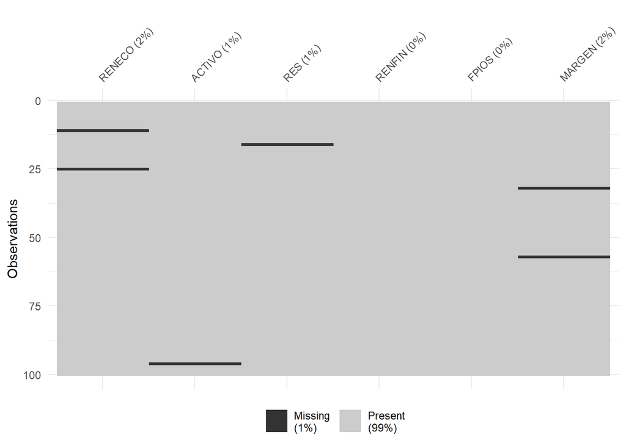

Casos con datos faltantes

|  | RENECO | ACTIVO | RES | RENFIN | FPIOS | MARGEN |
| --- | --- | --- | --- | --- | --- | --- |
| Viesgo Renovables SL. | NA | 269730.00 | 4609.000 | 3.200 | 177707.000 | 11.818 |
| Biovent Energia SA | 4.551 | 183899.00 | NA | 11.952 | 70033.000 | 22.792 |
| Sargon Energias SLU | NA | 85745.00 | -2216.000 | 26.900 | -10985.000 | -615.625 |
| Parc Eolic Sant Antoni SL | 1.361 | 69654.00 | 668.000 | 9.746 | 9727.000 | NA |
| Eolica La Brujula SA | 7.295 | 42146.98 | 2306.062 | 14.174 | 21694.791 | NA |
| La Caldera Energia Burgos SL | 2.643 | NA | 511.304 | -24.857 | -2752.605 | 14.448 |

```
##       RES               ACTIVO             FPIOS
##  Min.   : -5661.5   Min.   :   24944   Min.   : -77533
##  1st Qu.:   739.6   1st Qu.:   34249   1st Qu.:   2380
##  Median :  2114.7   Median :   46653   Median :  11936
##  Mean   : 12080.6   Mean   :  285091   Mean   : 128818
##  3rd Qu.:  3844.2   3rd Qu.:   83091   3rd Qu.:  27991
##  Max.   :727548.0   Max.   :13492812   Max.   :6904824
##
##      RENECO           RENFIN            LIQUIDEZ
##  Min.   :-2.813   Min.   :-359.773   Min.   :  0.0140
##  1st Qu.: 1.558   1st Qu.:   2.212   1st Qu.:  0.6675
##  Median : 4.236   Median :  15.924   Median :  1.0795
##  Mean   : 5.478   Mean   :  17.906   Mean   :  2.8401
##  3rd Qu.: 8.107   3rd Qu.:  34.167   3rd Qu.:  1.6350
##  Max.   :35.262   Max.   : 588.190   Max.   :128.4330
##
##     ENDEUDA            MARGEN            SOLVENCIA
##  Min.   :  0.917   Min.   :-2248.157   Min.   :-40.745
##  1st Qu.: 54.406   1st Qu.:   12.793   1st Qu.:  4.779
##  Median : 83.346   Median :   27.638   Median : 16.653
##  Mean   : 72.002   Mean   :    9.393   Mean   : 27.773
##  3rd Qu.: 95.289   3rd Qu.:   41.264   3rd Qu.: 43.812
##  Max.   :140.745   Max.   :  400.899   Max.   : 99.082
##  NA's   :2
##
##     APALANCA           MATRIZ           DIMENSION
##  Min.   :-8254.11   Length:94          Length:94
##  1st Qu.:   25.71   Class :character   Class :character
##  Median :  223.21   Mode  :character   Mode  :character
##  Mean   :  378.36
##  3rd Qu.:  670.30
##  Max.   :12244.35
```

```r
eolica_100_sm_info$grafico_vis_miss
eolica_100_sm_info$tabla_na
```

## 4.3 MATout

### 4.3.1 Uso:

```r
MATout(data, variable)
```

### 4.3.2 Objetivo

Detecta outliers en una variable numérica usando el rango intercuartílico (IQR) y los elimina.

### 4.3.3 Argumentos

- `data`: Dataframe con los datos.
- `variable`: Variable a analizar (sin comillas).

### 4.3.4 Salida

- Un dataframe sin outliers (`<nombre_original>_so`).
- Una lista con:
  - **Tabla de outliers detectados**.
  - **Gráfico de caja (boxplot)**.

### 4.3.5 Ejemplo

```r
MATout(data = eolica_100_sm, variable = RENECO)
```

### 4.3.6 Resultados Esperados

1. Un dataframe llamado `eolica_100_sm_so` con los datos filtrados.
2. Una lista `eolica_100_sm_so_info` que contiene:
   - Box-Plot de la variable analizada.
   - Tabla de valores atípicos.

**Visualización de Resultados:**

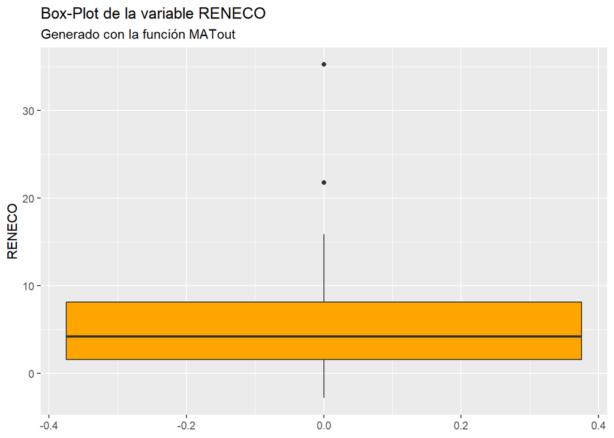

Casos considerados outliers

|  | RENECO |
| --- | --- |
| Molinos Del Ebro SA | 35.262 |
| Sierra De Selva SL | 21.761 |

```
##       RES               ACTIVO             FPIOS
##  Min.   : -5661.5   Min.   :   24944   Min.   : -77533
##  1st Qu.:   718.8   1st Qu.:   34437   1st Qu.:   2305
##  Median :  2016.7   Median :   46653   Median :  10870
##  Mean   : 12109.0   Mean   :  290312   Mean   : 131112
##  3rd Qu.:  3666.9   3rd Qu.:   84061   3rd Qu.:  28292
##  Max.   :727548.0   Max.   :13492812   Max.   :6904824
##
##      RENECO           RENFIN            LIQUIDEZ
##  Min.   :-2.813   Min.   :-359.773   Min.   :  0.0140
##  1st Qu.: 1.421   1st Qu.:   1.951   1st Qu.:  0.6915
##  Median : 4.144   Median :  15.460   Median :  1.1115
##  Mean   : 4.977   Mean   :  17.078   Mean   :  2.8952
##  3rd Qu.: 7.904   3rd Qu.:  33.163   3rd Qu.:  1.6567
##  Max.   :15.882   Max.   : 588.190   Max.   :128.4330
##
##     ENDEUDA            MARGEN            SOLVENCIA
##  Min.   :  0.917   Min.   :-2248.157   Min.   :-40.74
##  1st Qu.: 56.187   1st Qu.:   12.493   1st Qu.:  4.71
##  Median : 83.648   Median :   27.409   Median : 16.35
##  Mean   : 72.646   Mean   :    8.631   Mean   : 27.14
##  3rd Qu.: 95.388   3rd Qu.:   39.580   3rd Qu.: 43.80
##  Max.   :140.745   Max.   :  400.899   Max.   : 99.08
##  NA's   :2
##
##     APALANCA           MATRIZ           DIMENSION
##  Min.   :-8254.11   Length:92          Length:92
##  1st Qu.:   26.17   Class :character   Class :character
##  Median :  233.75   Mode  :character   Mode  :character
##  Mean   :  385.76
##  3rd Qu.:  693.49
##  Max.   :12244.35
```

```r
eolica_100_sm_so_info$Boxplot
eolica_100_sm_so_info$Outliers_Table
```

## 4.4 MATout_Mahalanobis

### 4.4.1 Uso:

```r
MATout_Mahalanobis(data, variables)
```

### 4.4.2 Objetivo

Usa la distancia de Mahalanobis para detectar y eliminar outliers multivariados en un conjunto de variables.

### 4.4.3 Argumentos

- `data`: Dataframe con los datos.
- `variables`: Variables a incluir en el análisis (sin comillas, separadas por comas).

### 4.4.4 Salida

- Un dataframe sin outliers (`<nombre_original>_so`).
- Una lista con:
  - **Tabla de outliers detectados**.
  - **Boxplot de distancias de Mahalanobis**.

### 4.4.5 Ejemplo

```r
MATout_Mahalanobis(data = eolica_100_sm,
                   variables = c(RENECO, ACTIVO, RES, RENFIN, FPIOS, MARGEN))
```

### 4.4.6 Resultados Esperados

1. Un dataframe llamado `eolica_100_sm_so` con los datos filtrados.
2. Una lista `eolica_100_sm_so_info` que contiene:
   - Tabla de valores atípicos.
   - Gráficos de las distancias de Mahalanobis.

**Visualización de Resultados:**

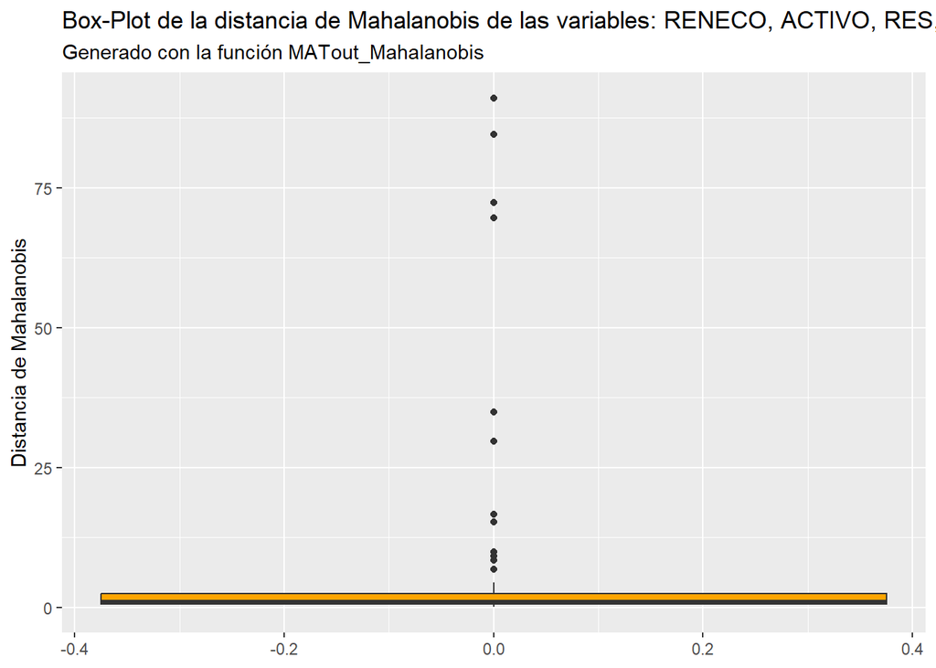

Casos considerados outliers

|  | Mahalanobis_Distance | RENECO | ACTIVO | RES | RENFIN | FPIOS | MARGEN |
| --- | --- | --- | --- | --- | --- | --- | --- |
| Holding De Negocios De GAS SL. | 91.048060 | 5.264 | 13492812.00 | 727548.0000 | 10.287 | 6904824.0000 | 91.152 |
| Global Power Generation SA. | 72.365163 | 1.393 | 2002458.00 | 39995.0000 | 1.603 | 1740487.0000 | 22.403 |
| Naturgy Renovables SLU | 69.684700 | 1.959 | 1956869.00 | 42737.0000 | 12.043 | 318475.0000 | 20.442 |
| Corporacion Acciona Eolica SL | 8.471773 | 4.562 | 864606.00 | 29592.0000 | 28.990 | 136064.0000 | 20.091 |
| Saeta Yield SA. | 16.650544 | 0.360 | 796886.38 | 2084.4760 | 0.432 | 665319.5560 | 16.258 |
| Parque Eolico Santa Catalina SL | 15.261169 | 4.053 | 147742.52 | 3645.2780 | -359.773 | -1664.7550 | 31.780 |
| Molinos Del Ebro SA | 29.667488 | 35.262 | 62114.37 | 17026.2569 | 81.149 | 26991.0714 | 41.821 |
| Luria De Energias SA | 6.816766 | 4.844 | 49912.00 | 1849.0000 | 267.774 | 903.0000 | 20.160 |
| Parque Eolico Sierra De Las Carbas SL | 8.424602 | 3.676 | 46949.76 | 1252.4250 | -263.639 | -654.7640 | 19.056 |
| Elecdey Lezuza SA | 34.902738 | 4.657 | 36061.15 | 1258.6609 | 588.190 | 285.5387 | 22.346 |
| WPD Parque Eolico Navillas SL. | 84.604706 | -0.416 | 35511.45 | -110.9293 | -14.302 | 1034.1284 | -2248.157 |
| Sierra De Selva SL | 9.134843 | 21.761 | 27728.00 | 4525.0000 | 30.856 | 19555.0000 | 47.045 |
| El Paramo Parque Eolico SL | 9.970725 | 3.416 | 26634.00 | 671.0000 | -287.974 | -316.0000 | 16.267 |

```
##       RES              ACTIVO            FPIOS
##  Min.   :-5661.5   Min.   :  24944   Min.   :-77533
##  1st Qu.:  650.7   1st Qu.:  33607   1st Qu.:  2842
##  Median : 1949.0   Median :  43998   Median : 10980
##  Mean   : 3253.1   Mean   :  89534   Mean   : 28365
##  3rd Qu.: 3497.5   3rd Qu.:  79873   3rd Qu.: 25995
##  Max.   :67033.0   Max.   :1275939   Max.   :726783
##
##      RENECO           RENFIN            LIQUIDEZ
##  Min.   :-2.813   Min.   :-165.348   Min.   :  0.029
##  1st Qu.: 1.424   1st Qu.:   6.904   1st Qu.:  0.690
##  Median : 4.237   Median :  16.684   Median :  1.177
##  Mean   : 5.236   Mean   :  19.599   Mean   :  3.129
##  3rd Qu.: 8.560   3rd Qu.:  34.669   3rd Qu.:  1.648
##  Max.   :15.882   Max.   : 207.801   Max.   :128.433
##
##     ENDEUDA            MARGEN          SOLVENCIA
##  Min.   :  0.917   Min.   :-302.03   Min.   :-40.745
##  1st Qu.: 56.193   1st Qu.:  11.66   1st Qu.:  5.981
##  Median : 83.098   Median :  28.52   Median : 16.901
##  Mean   : 72.071   Mean   :  34.10   Mean   : 27.670
##  3rd Qu.: 94.059   3rd Qu.:  42.02   3rd Qu.: 43.796
##  Max.   :140.745   Max.   : 400.90   Max.   : 99.082
##  NA's   :2
##
##     APALANCA           MATRIZ           DIMENSION
##  Min.   :-7770.00   Length:81          Length:81
##  1st Qu.:   31.93   Class :character   Class :character
##  Median :  239.37   Mode  :character   Mode  :character
##  Mean   :  435.09
##  3rd Qu.:  684.22
##  Max.   : 8049.39
```

```r
eolica_100_sm_so_info$Boxplot
eolica_100_sm_so_info$Outliers_Table
```

## 4.5 MATdescribe

### 4.5.1 Uso:

```r
MATdescribe(data, variable)
```

### 4.5.2 Objetivo

Esta función realiza un análisis descriptivo y gráfico detallado de una variable numérica en un dataframe. Incluye histogramas, densidad, boxplots y pruebas de normalidad.

### 4.5.3 Argumentos

- `data`: Dataframe que contiene los datos.
- `variable`: Variable numérica a analizar (sin comillas).
- `bins`: Número de bins para el histograma. Si es 0, o no se especifica, se usa el método Freedman-Diaconis para calcular el número de intervalos de valores en el histograma.

### 4.5.4 Salida

Genera un objeto en el entorno global con el nombre `<variable>_describe_info`, que incluye: - **Resumen gráfico** (histograma, densidad, boxplot, QQ-Plot). - **Estadísticos descriptivos** (media, mediana, asimetría, curtosis, etc.). - **Pruebas de normalidad** (Shapiro-Wilk, Kolmogorov-Smirnov, Anderson-Darling).

### 4.5.5 Ejemplo

```r
MATdescribe(eolica_100_sm_so, RENECO, bins = 0)
```

### 4.5.6 Resultados Esperados

1. Una lista llamada `RENECO_describe_info` que contiene:
   - Gráfico resumen con varios paneles.
   - Tabla de estadísticos descriptivos.
   - Resultado de las pruebas de normalidad de Shapiro-Wilk, Kolmogorov-Smirnov y Anderson-Darling (para significación de 0.05).

**Visualización de Resultados:**

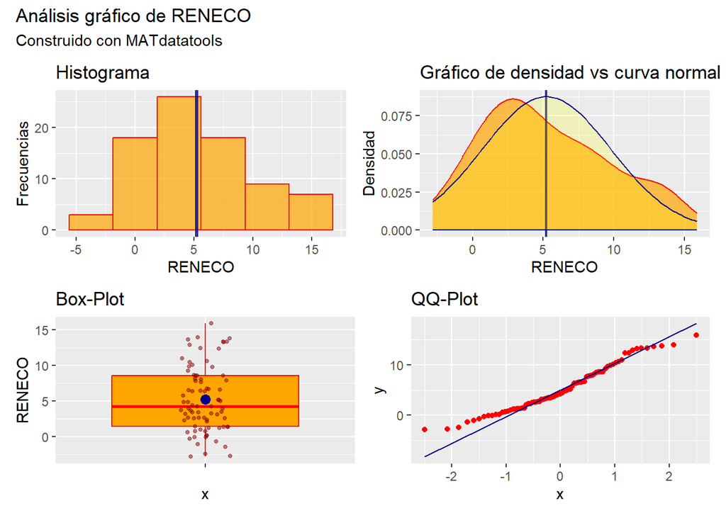

```r
RENECO_describe_info$grafico_resumen
```

```r
RENECO_describe_info$estadisticos
```

Principales Estadísticos de RENECO

| Media | Desviación Típica | Mediana | Valor mínimo | Valor máximo | C. Asimetría Fisher | C. Curtosis Fisher |
| --- | --- | --- | --- | --- | --- | --- |
| 5.236346 | 4.554305 | 4.237 | -2.813 | 15.882 | 0.4115856 | -0.6729009 |

```r
RENECO_describe_info$normalidad
```

RENECO - Pruebas de Normalidad

| Prueba | p-valor | Conclusión |
| --- | --- | --- |
| Shapiro-Wilk | 0.026 | NO-NORMALIDAD |
| Kolmogorov-Smirnov | 0.080 | NORMALIDAD |
| Anderson-Darling | 0.024 | NO-NORMALIDAD |

```r
RENECO_describe_info$grafico_resumen
RENECO_describe_info$estadisticos
RENECO_describe_info$normalidad
```

## 4.6 MATtaf

### 4.6.1 Uso:

```r
MATtaf(data, variable, breaks = NULL)
```

### 4.6.2 Objetivo

Generar una tabla de frecuencias agrupadas en intervalos y un histograma relacionado.

### 4.6.3 Argumentos

- `data`: Dataframe con los datos.
- `variable`: Variable numérica a analizar.
- `breaks`: Número de intervalos (opcional, se calcula automáticamente si no se especifica, mediante el método de Freedman-Diaconis).

### 4.6.5 Ejemplo

```r
MATtaf(eolica_100_sm_so, RENECO)
```

### 4.6.6 Resultados Esperados

**Visualización de Resultados:**

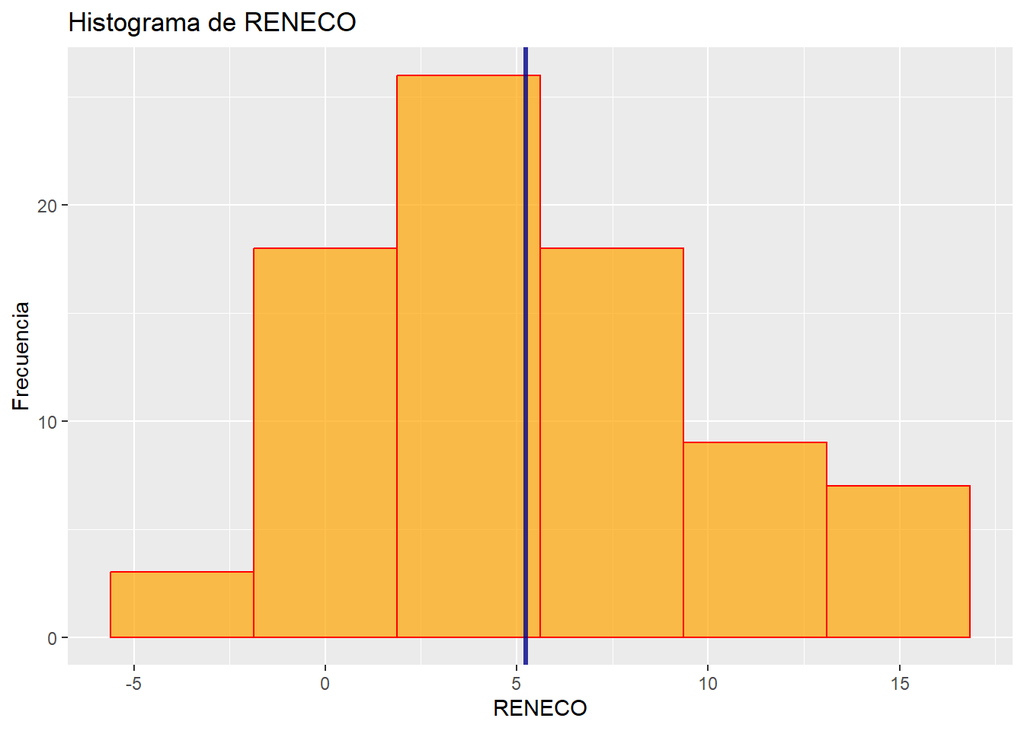

```r
RENECO_intervalos_frecuencia$histograma
```

```r
RENECO_intervalos_frecuencia$tabla
```

Distribución de frecuencias agrupadas en intervalos de RENECO

| Intervalo | Frecuencia absoluta n(i) | Frecuencia absoluta acum. N(i) | Frecuencia relativa f(i) | Frecuencia relativa acum. F(i) |
| --- | --- | --- | --- | --- |
| [-2.83,0.303] | 11 | 11 | 0.136 | 0.14 |
| (0.303,3.42] | 22 | 33 | 0.272 | 0.41 |
| (3.42,6.53] | 19 | 52 | 0.235 | 0.64 |
| (6.53,9.65] | 13 | 65 | 0.160 | 0.80 |
| (9.65,12.8] | 8 | 73 | 0.099 | 0.90 |
| (12.8,15.9] | 8 | 81 | 0.099 | 1.00 |

```r
RENECO_intervalos_frecuencia$histograma
RENECO_intervalos_frecuencia$tabla
```

# 5 Documentación del Paquete

- **Autor:** Miguel Ángel Tarancón miguelangel.tarancon@uclm.es
- **Versión:** 0.1.0
- **Fecha:** 2025-02-14
- **Licencia:** MIT

# 6 ¡Empieza a explorar tus datos con MATdatatools!

Este paquete está diseñado para facilitarte el trabajo y ayudarte a generar análisis rápidos y visuales. ¡Pruébalo hoy y optimiza tus estudios de datos!